# t07-introduction-to-three-phase-systems – My Notes

## Some General Knowledge

| Process | Voltage | Phase |
| --- | --- | --- |
| Generation | 11-15 kV | 3 phase |
| Transmission | 100-400 kV | 3 phase |
| Distribution | 11 kV | 3 phase |
| Consumption | 415 V or 240 V | 3 phase or single phase |

Cycle of electricity transfer from power plan to a house:

- Power Plant
- Step-up transformer
- High-voltage Transmission line
- Step-down transformer (substation)

| Wire Colour | Notation |
| --- | --- |
| R red | L1 |
| Y yellow | L2 |
| B blue | L3 |
| N |  |

## Three-Phase Generator:

Voltage differences between wires: - $415~V$ between line and line - $240~V$ between line and neutral

$$\begin{align*}
e_{AN} &= E_{m(AN)} \sin \omega t \\
e_{BN} &= E_{m(VN)} \sin (\omega t - 120^\circ) \\
e_{CN} &= E_{m(CN)} \sin (\omega t + 120^\circ) \\
\end{align*}$$

Phase sequence change can change the direction of turns of a motor

Motor:

| Delta connection | Y (Wye) connection |
| --- | --- |
| No common point | Has common point |

## Y-Connected Generator

$E_L = V_\phi \sqrt{3}$

$I_L = I_\phi$

- Sum of line voltages is $0~\text{V}$.
- Phase rotation, or phase sequence, is the order in which the voltage waveforms of a polyphase AC source reach their respective peaks.
- The phase sequence can be determined by the order in which the phasors pass through a fixed point on the phasor diagram if the phasors are rotated in a counterclockwise direction.
- The phase sequence for the line voltages is the same as for phase voltages.
- The phase sequence is quite important in the three-phase distribution of power.
- In a three-phase motor, for example, if two phase voltages are interchanged, the sequence will change, and the direction of rotation of the motor will be reversed.
- If the load is balanced, the neutral connection can be removed without affecting the circuit in any manner; that is, if $Z_1 = Z_2 = Z_3$ then $I_N$ will be zero.

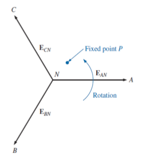

## Y-Connected Generator with a Y-Connected Load

$E_L = V_\phi \sqrt{3}$

$I_L = I_\phi$

## Y-$\Delta$ System

$V_L = V_\phi$

$I_L = I_\phi \cdot \sqrt{3}$

## Three-Wattmeter Method

$P_{T_Y} = P_1 + P_2 + P_3$